# Quiz 250414 (Wason Selection Task)

coop711

2025-04-14

# 7주차 데이터 실험 집계

## 실험의 목적

7주차 구글 예습 설문지 집계결과를 분석합니다.

Q1 ~ Q6에서는 랜덤화의 효과로 Red, Black 이 얼마나 닮았는지 알아봅니다.

Q7 ~ Q8에서는 Wason Selection Task에서 추상적 문제에 취약하고 인지적 편향에 쏠리는 우리의 모습을 파악합니다. 같은 구조의 문제를 추상적으로 표현할 때와 구체적인 사례를 들어 표현할 때 정답률이 매우 차이나는 것을 살펴보고 인지적 편향을 어떻게 확인하는지 그리고 학습 방법에 대한 추론까지 진행해 봅니다.

제출시간의 분포가 날마다 고른지, Red, Black 간에는 닮았는지 알아봅니다.

### Red, Black을 잘못 표시한 사람들

|  | Red(구글예습퀴즈) | Black(구글예습퀴즈) |
| --- | --- | --- |
| **Red(랜덤화출석부)** | 266 | 2 |
| **Black(랜덤화출석부)** | 0 | 264 |
| **계** | 266 | 266 |

랜덤화출석부에 있는 Red, Black 과 실제 구글설문에 올린 Red, Black 이 다른 사람들의 수효는 2명입니다.

Red를 Black 이라고 한 사람이 2명, Black 을 Red 라고 한 사람이 0명입니다.

두 가지 방법으로 분석합니다.

우선 Red, Black 을 잘못 선택한 2명을 랜덤하게 둘로 나누면 어느 한 쪽 집단에 들어갈 기대인원은 2명을 둘로 나눈 1(명)이고, 표준오차는 2의 제곱근에 1/2을 곱해 준 0.7명이 됩니다.

실제로 Red를 Black 이라고 한 사람수, 2명이나 Black 을 Red 라고 한 사람수, 0명은 기대인원으로부터 표준오차 범위는 벗어 나지만 표준오차 두 배 범위에는 잘 들어갑니다.

두 번째 분석 방법은 확률을 계산해 보는 것입니다.

Red, Black 을 잘못 선택한 2명을 랜덤하게 둘로 나눌 때, 실제로 관찰된 2명 이상이나 0명이하로 잘못 선택한 사람수가 나올 가능성은 얼마나 되는가 입니다.

이 경우 공평한 동전던지기를 확률 법칙으로 표현한 이항분포로부터 계산할 수 있습니다.

시행횟수가 2이고 한 번 시행에서 성공확률이 1/2 인 이항분포에서 성공횟수가 0이하이거나 2이상을 관찰할 확률은 0.5입니다.

공평한 동전 던지기에서 앞면이 0개 이하 나오는 확률은 2개 이상 나오는 확률과 같기 때문에 사실상 한쪽만 계산해서 2배 해 주면 됩니다.

이 값을 p-value 라고 하는데, p-value가 0.05보다 작을 때 **통계적으로 유의한 차이를 관찰**하였다고 말합니다.

즉, 공평한 동전을 던지는 것과 같은 과정이라고 가정하였을 때 실제로 관찰된 값들이 가정으로부터 얼마나 떨어져 있는지를 표현한 것입니다.

0.05는 이런 실험을 스무 번 정도 반복하면 1번 나올 정도로 드문 사건을 의미합니다.

즉 가정이 잘못되었다는 것입니다.

그런데 Red, Black 을 잘못 표시한 사람들의 분포에서 관찰된 p-value 는 0.05와는 비교도 안될 정도로 큰 값입니다.

따라서 두 집단이 랜덤화 효과가 작동하여 **통계적으로 유의한 차이를 보이지 않는다**고 할 수 있습니다.

### 응답인원의 Red, Black

Red 로 응답한 인원은 266명, Black 에 응답한 인원은 266명입니다.

전체 응답인원 532 명을 랜덤하게 둘로 나눌 때 어느 한 쪽의 기대인원은 전체 응답인원의 절반인 266명이고, 표준오차는 전체 응답인원의 제곱근에 1/2을 곱해 준 11.5 명입니다.

따라서 Red, Black 각 그룹에 관찰된 인원은 기대인원으로부터 표준오차 범위 안에 들어갑니다.

## Q1. 통계학의 기본원리

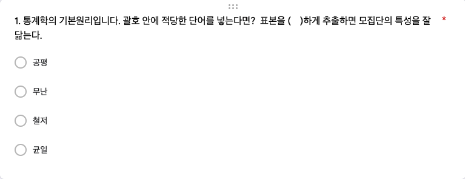

### 공평하게 추출하면 …

|  | 공평 | 무난 | 철저 | 균일 | 계 |
| --- | --- | --- | --- | --- | --- |
| **Red** | 203 | 8 | 5 | 50 | 266 |
| **Black** | 211 | 9 | 6 | 40 | 266 |
| **계** | 414 | 17 | 11 | 90 | 532 |

Pearson’s Chi-squared test: `.`

| Test statistic | df | P value |
| --- | --- | --- |
| 1.415 | 3 | 0.7019 |

Q1의 집계 결과가 Red, Black 간에 통계적으로 유의한 차이가 있는지 알아보기 위하여 카이제곱 테스트를 수행하였습니다.

그 결과 카이제곱 통계량은 1.42, 자유도는 3 , p-value 는 0.70이므로 Red, Black 간에 통계적으로 유의한 차이를 보이지 않습니다.

실제로 닮은 게 느껴집니까?

### 공평하게 추출하면 … (%)

| 공평 | 무난 | 철저 | 균일 | 계 |
| --- | --- | --- | --- | --- |
| 77.8 | 3.2 | 2.1 | 16.9 | 100.0 |

정답률은 Red, Black 을 합하여 계산하는데, 77.8(%) 입니다.

## Q2. 리터러리 다이제스트의 실패

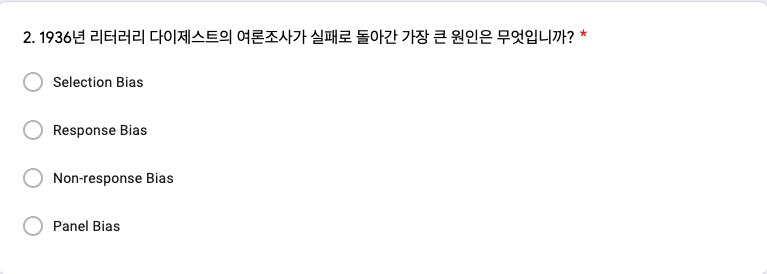

### Selection Bias

|  | Selection Bias | Response Bias | Non-response Bias | Panel Bias | 계 |
| --- | --- | --- | --- | --- | --- |
| **Red** | 191 | 33 | 38 | 4 | 266 |
| **Black** | 189 | 23 | 40 | 14 | 266 |
| **계** | 380 | 56 | 78 | 18 | 532 |

Pearson’s Chi-squared test: `.`

| Test statistic | df | P value |
| --- | --- | --- |
| 7.403 | 3 | 0.0601 |

Q2의 집계 결과가 Red, Black 간에 통계적으로 유의한 차이가 있는지 알아보기 위하여 카이제곱 테스트를 수행하였습니다.

그 결과 카이제곱 통계량은 7.40, 자유도는 3, p-value 는 0.06이므로 Red, Black 간에 통계적으로 유의한 차이를 보이지 않습니다.

실제로 닮은 게 느껴집니까?

### Selection Bias (%)

| Selection Bias | Response Bias | Non-response Bias | Panel Bias | 계 |
| --- | --- | --- | --- | --- |
| 71.4 | 10.5 | 14.7 | 3.4 | 100.0 |

정답률은 Red, Black 을 합하여 계산하는데, 71.4(%) 입니다.

## Q3. 1948년, 여론조사가 듀이를 당선시킨 해

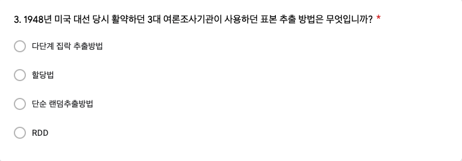

### 할당법의 문제점

|  | 다단계 집락 추출방법 | 할당법 | 단순 랜덤추출방법 | RDD | 계 |
| --- | --- | --- | --- | --- | --- |
| **Red** | 20 | 197 | 39 | 10 | 266 |
| **Black** | 29 | 184 | 45 | 8 | 266 |
| **계** | 49 | 381 | 84 | 18 | 532 |

Pearson’s Chi-squared test: `.`

| Test statistic | df | P value |
| --- | --- | --- |
| 2.747 | 3 | 0.4322 |

Q3의 집계 결과가 Red, Black 간에 통계적으로 유의한 차이가 있는지 알아보기 위하여 카이제곱 테스트를 수행하였습니다.

그 결과 카이제곱 통계량은 2.75, 자유도는 3, p-value 는 0.43이므로 Red, Black 간에 통계적으로 유의한 차이를 보이지 않습니다.

실제로 닮은 게 느껴집니까?

### 할당법의 문제점(%)

| 다단계 집락 추출방법 | 할당법 | 단순 랜덤추출방법 | RDD | 계 |
| --- | --- | --- | --- | --- |
| 9.2 | 71.6 | 15.8 | 3.4 | 100.0 |

정답률은 Red, Black 을 합하여 계산하는데, 71.6(%) 입니다.

## Q4. 1948 미 대선 이후

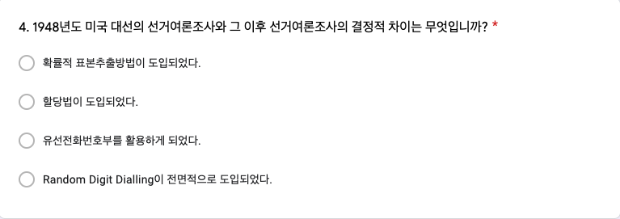

### 확률적 표본추출방법 도입

|  | 확률적 표본추출 | 할당법 | 유선전화번호부 | RDD도입 | 계 |
| --- | --- | --- | --- | --- | --- |
| **Red** | 196 | 30 | 22 | 18 | 266 |
| **Black** | 206 | 20 | 16 | 24 | 266 |
| **계** | 402 | 50 | 38 | 42 | 532 |

Pearson’s Chi-squared test: `.`

| Test statistic | df | P value |
| --- | --- | --- |
| 4.053 | 3 | 0.2558 |

Q4의 집계 결과가 Red, Black 간에 통계적으로 유의한 차이가 있는지 알아보기 위하여 카이제곱 테스트를 수행하였습니다.

그 결과 카이제곱 통계량은 4.05, 자유도는 3, p-value 는 0.26이므로 Red, Black 간에 통계적으로 유의한 차이를 보이지 않습니다.

실제로 닮은 게 느껴집니까?

### 확률적 표본추출방법 도입 … (%)

| 확률적 표본추출 | 할당법 | 유선전화번호부 | RDD도입 | 계 |
| --- | --- | --- | --- | --- |
| 75.6 | 9.4 | 7.1 | 7.9 | 100.0 |

정답률은 Red, Black 을 합하여 계산하는데, 75.6(%) 입니다.

## Q5. 표본오차를 반으로 줄이려면?

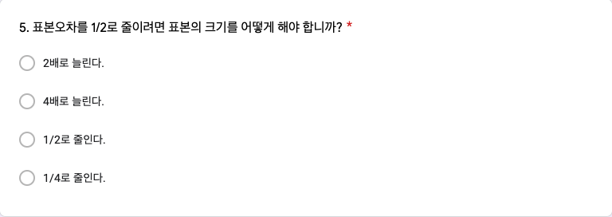

### 4배로 늘려야

|  | 2배로 | 4배로 | 1/2로 | 1/4로 | 계 |
| --- | --- | --- | --- | --- | --- |
| **Red** | 46 | 188 | 20 | 12 | 266 |
| **Black** | 57 | 182 | 21 | 6 | 266 |
| **계** | 103 | 370 | 41 | 18 | 532 |

Pearson’s Chi-squared test: `.`

| Test statistic | df | P value |
| --- | --- | --- |
| 3.296 | 3 | 0.3481 |

Q5의 집계 결과가 Red, Black 간에 통계적으로 유의한 차이가 있는지 알아보기 위하여 카이제곱 테스트를 수행하였습니다.

그 결과 카이제곱 통계량은 3.30, 자유도는 3, p-value 는 0.35이므로 Red, Black 간에 통계적으로 유의한 차이를 보이지 않습니다.

실제로 닮은 게 느껴집니까?

### 4배로 눌려야 (%)

| 2배로 | 4배로 | 1/2로 | 1/4로 | 계 |
| --- | --- | --- | --- | --- |
| 19.4 | 69.5 | 7.7 | 3.4 | 100.0 |

정답률은 Red, Black 을 합하여 계산하는데, 69.5(%) 입니다.

## Q6. 대선 여론조사의 목표모집단?

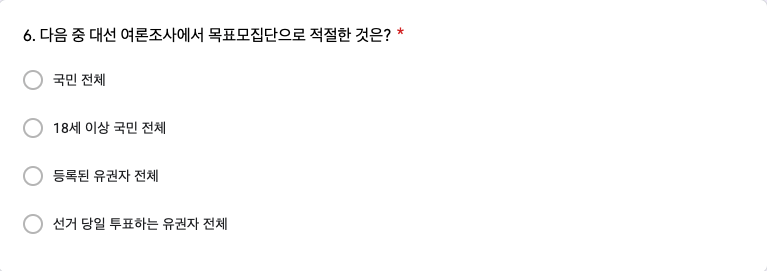

### 선거당일 투표하는 유권자 전체

|  | 국민 전체 | 18세 이상 국민 전체 | 등록된 유권자 전체 | 선거 당일 투표하는 유권자 전체 | 계 |
| --- | --- | --- | --- | --- | --- |
| **Red** | 14 | 59 | 35 | 158 | 266 |
| **Black** | 15 | 62 | 37 | 152 | 266 |
| **계** | 29 | 121 | 72 | 310 | 532 |

Pearson’s Chi-squared test: `.`

| Test statistic | df | P value |
| --- | --- | --- |
| 0.2805 | 3 | 0.9636 |

Q6의 집계 결과가 Red, Black 간에 통계적으로 유의한 차이가 있는지 알아보기 위하여 카이제곱 테스트를 수행하였습니다.

그 결과 카이제곱 통계량은 0.28, 자유도는 3, p-value 는 0.96이므로 Red, Black 간에 통계적으로 유의한 차이를 보이지 않습니다.

실제로 닮은 게 느껴집니까?

### 선거당일 투표하는 유권자 전체(%)

| 국민 전체 | 18세 이상 국민 전체 | 등록된 유권자 전체 | 선거 당일 투표하는 유권자 전체 | 계 |
| --- | --- | --- | --- | --- |
| 5.5 | 22.7 | 13.5 | 58.3 | 100.0 |

정답률은 Red, Black 을 합하여 계산하는데, 58.3(%) 입니다.

## Wason Selection Task

같은 구조의 문제를 추상적으로 물어볼 때와 구체적으로 사례를 들어서 물어볼 때의 정답률에 큰 차이가 있음에 유의하세요.

Red 집단에게는 추상적 질문을 먼저 던지고, 구체적 사례를 든 질문을 나중에 던졌으며 Black 집단에게는 구체적 사례를 든 질문을 먼저 던지고, 추상적 질문을 나중에 던졌습니다.

추상적인 질문에 대해서는 매우 낮은 정답률을 보이지만 구체적인 질문에 대해서는 정답률이 훨씬 올라가는 것을 관찰할 수 있습니다.

추상적인 질문에 쩔쩔매는 것이 정상입니다.

Wason Selection Task 는 인지 편향, 그 중에서도 확증 편향이 많은 사람들에게 공통적으로 나타난다는 것을 보여줍니다.

반증의 근거가 되는 자료는 잘 들여다 보려 하지 않습니다.

이 실험 결과의 어느 부분이 이를 입증하는 지 살펴 봅니다.

### Red. Q7에 추상적 문제, Q8에 구체적 문제

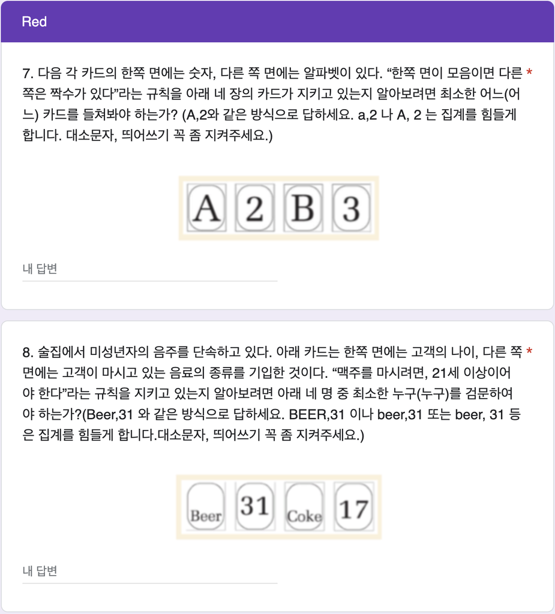

### Black. Q7에 구체적 문제, Q8에 추상적 문제

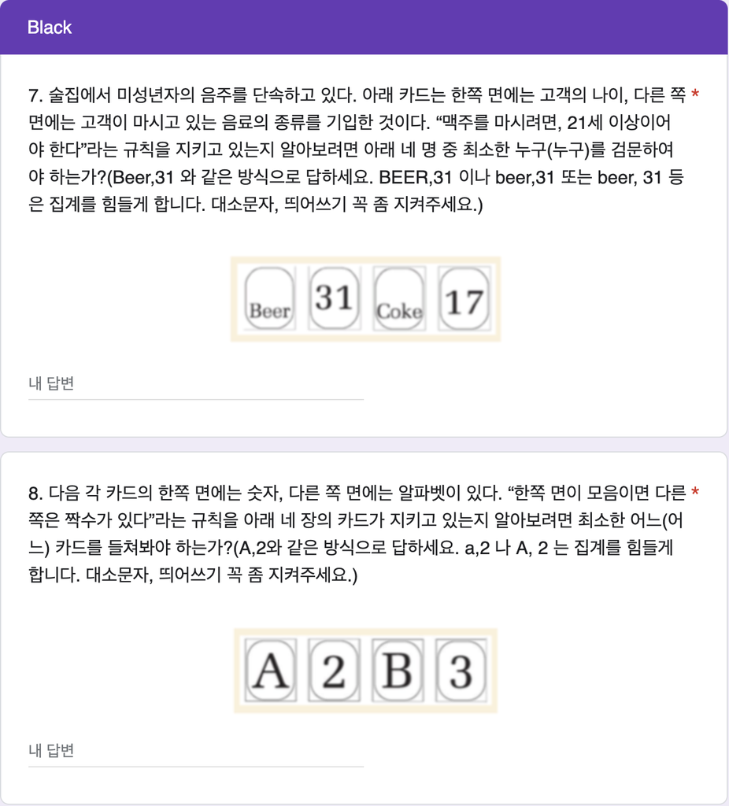

## Q7. Red에 추상적 질문, Black에 구체적 질문

“한쪽 면이 모음이면 다른 쪽은 짝수가 있다.”

이 규칙은 “X이면 Y이다”의 형식으로 되어 있습니다.

이 논리식과 동등한 것은 **대우**인 “Y가 아니면 X가 아니다”입니다.

매우 불편한 구조이죠.

그렇다 보니까 이게 잘 떠오를 리가 없습니다.

’선거여론조사의 발달’에서 학습한 바 있는 “표본을 공평하게 뽑으면 모집단의 특성을 잘 닮는다”의 대우가 바로 “모집단을 닮지 않으면 표본을 공평하게 뽑지 않은 것이다”입니다.

즉, 표본을 공평하게 뽑지 않아서 모집단을 제대로 닮지 않은 표본을 뽑았다는 것이죠.

주어진 네 장의 카드 중에서 한쪽 면이 모음인 것은 A입니다.

따라서 A는 우선 들쳐봐야 하는 카드이고, “한쪽 면이 모음이면 다른 쪽은 짝수가 있다”의 대우는 “한쪽 면이 짝수가 아니면 다른 쪽 면이 모음이 아니다”, 즉 “한쪽 면이 홀수이면 다른 쪽 면은 자음이다”가 됩니다.

짝수가 아니면 홀수이고, 모음이 아니면 자음이니까요.

따라서 홀수 카드를 들쳐봐야 합니다.

그래서 A,3 두 장을 들쳐보면 됩니다.

맥주와 연령 문제는 실생활과 밀접한 구체적인 사안이어서 “어, 맥주 마시는 사람 신분증 좀 보여주세요, 17살 미성년자는 지금 마시는 것이 맥주인가요?”하고 묻는 데 익숙하지만 직관적으로 Beer와 17을 검문해야 한다고 추론하였는지 논증하는 연습이 필요합니다.

“맥주를 마시려면, 21세 이상이어야 한다”라는 규칙으로부터 “맥주”를 검문해야 하고, 검문으로부터 나이를 확인합니다.

그리고 이 규칙과 동등한 대우인 “21세 이상이 아니면, 맥주를 마실 수 없다”, 즉, “21세 미만이면 맥주를 마실 수 없다”로부터 “21세 미만”인 “17세”를 검문해야 하는 것입니다.

물론 실생활에서 접할 수 있는 문제이기 때문에 미성년자가 맥주를 마시고 있는 것은 아닌지 Beer와 17을 골라야 한다고 쉽게 답할 수 있지만 그 배경에는 이러한 논리가 숨어 있습니다.

### 집계

Red에 추상적 질문, Black에 구체적 질문

|  | 정답 | 오답 | 계 |
| --- | --- | --- | --- |
| **Red(추상적 질문)** | 101 | 165 | 266 |
| **Black(구체적 질문)** | 171 | 95 | 266 |
| **계** | 272 | 260 | 532 |

{A, 2, B, 3}에서 어느 카드를(들을) 골라야 “한쪽 면이 모음이면, 다른 쪽 면은 짝수이다”라는 규칙을 지키고 있는 지 확인할 수 있는가? 라는 질문을 Red에 배치하고, {Beer, 31, Coke, 17}에서 누구를(들을) 검문해야 하는가라는 질문을 Black에 배치했습니다.

Red의 경우 총 266(명)이 응답하였고 101(명)이 정답인 {A, 3}를 올렸습니다.

구체적인 상황에 놓인 Black의 경우 총 266(명)이 응답하였고 171(명)이 정답인 {Beer,17}을 올려서 구체적인 질문에 압도적으로 많은 정답이 나온 것을 알 수 있습니다.

이를 백분율로 비교해 보면

### % 비교

|  | 정답 | 오답 | 계 |
| --- | --- | --- | --- |
| **Red(추상적 질문)** | 38.0 | 62.0 | 100.0 |
| **Black(구체적 질문)** | 64.3 | 35.7 | 100.0 |

추상적인 질문으로 이루어진 Red에서는 38.0(%)가 정답을 올렸고, 구체적인 질문으로 이루어진 Black에서는 64.3(%)가 정답을 올려서 구체적인 질문에 압도적으로 많은 정답이 올라왔다는 것을 알 수 있습니다.

이 상황을 Mosiac Plot으로 살펴보겠습니다.

### Mosaic Plot

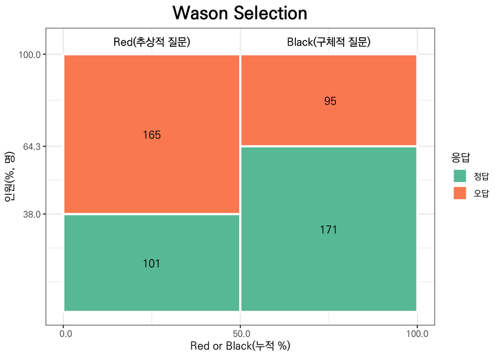

Mosaic Plot으로부터 추상적 질문이 주어진 Red 에서 정답 비율이 구체적 질문이 주어진 Black 에서 정답 비율에 비해서 매우 적다는 것을 시각적으로 파악할 수 있습니다.

## Q8. Red에 구체적 질문, Black에 추상적 질문

Q8에서는 Q7과 반대로 Red에 구체적 질문, Black에 추상적 질문을 배치하였습니다.

이렇게 하므로써 질문지에 응답한 모든 사람은 한 번씩 구체적 질문과 추상적 질문에 답할 수 있게 되었습니다.

집계 결과는 비슷합니다.

다만, 이렇게 추상적 질문을 먼저 배치하고 구체적 질문을 나중에 배치하느냐, 혹은 그 반대로 구체적 질문을 먼저 배치하고 추상적 질문을 나중에 배치한 것의 영향이 있는지를 파악한다면 학습 순서가 정답률과 어떤 관계가 있는지 파악할 수 있지 않을까 합니다.

### 집계

Red에 구체적 질문, Black에 추상적 질문

|  | 정답 | 오답 | 계 |
| --- | --- | --- | --- |
| **Red(구체적 질문)** | 152 | 114 | 266 |
| **Black(추상적 질문)** | 72 | 194 | 266 |
| **계** | 224 | 308 | 532 |

구체적인 질문을 배치한 Red의 경우 총 266(명)이 응답하였고 152(명)이 정답인 {Beer, 17}(을)를 올렸습니다.

추상적인 질문을 배치한 Black의 경우 총 266(명)이 응답하였고 72(명)이 정답인 {A,3}(을)를 올려서 구체적인 질문에 압도적으로 많은 정답이 나온 것을 알 수 있습니다.

이를 백분율로 비교해 보면

### % 비교.

|  | 정답 | 오답 | 계 |
| --- | --- | --- | --- |
| **Red(구체적 질문)** | 57.1 | 42.9 | 100.0 |
| **Black(추상적 질문)** | 27.1 | 72.9 | 100.0 |

구체적인 질문을 배치한 Red에서는 57.1(%)가 정답을 올렸고, 추상적인 질문을 배치한 Black에서는 27.1(%)가 정답을 올려서 구체적인 질문에 압도적으로 많은 정답이 올라왔다는 것을 알 수 있습니다.

이 상황을 Mosaic Plot으로 살펴보겠습니다.

### Mosaic Plot

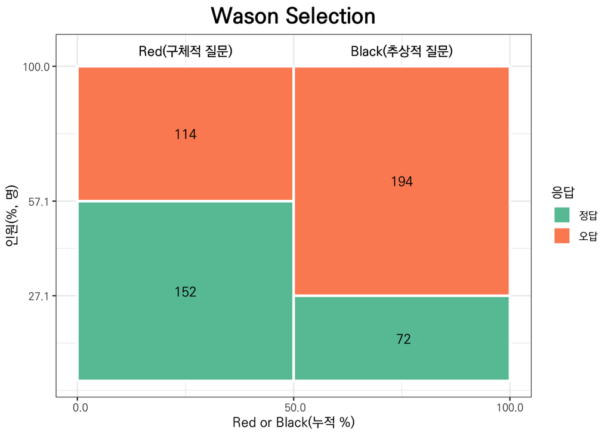

Mosaic Plot으로부터 구체적 질문이 주어진 Red 의 정답 비율이 추상적 질문이 주어진 Black의 정답 비율에 비해서 매우 높다는 것을 시각적으로 파악할 수 있습니다.

## Q9. 인지적 편향과 오류

Wason Selection Task 에서 많은 사람들이 겪는 흔한 오류(예 : 확증편향)을 설명합니다.

사람들은 보통 자신의 가설을 확인하기 위한 정보만 찾고, 반례가 될 수 있는 카드는 무시하려는 경향이 있습니다.

Peter C. Wason (1924-2003)의 연구에 의하면 정답을 찾아내는 백분율은 10%에 불과합니다.

여러분의 응답과 비교해 보세요.

### 집계

Wason Selection Task 인지편향 분석

|  | A,2 | A,3 | Other | 계 |
| --- | --- | --- | --- | --- |
| **Red(추상적 질문 먼저)** | 96 | 95 | 75 | 266 |
| **Black(구체적 질문 먼저)** | 119 | 61 | 86 | 266 |
| **계** | 215 | 156 | 161 | 532 |

{A, 2, B, 3}에서 어느 카드를(들을) 골라야 “한쪽 면이 모음이면, 다른 쪽 면은 짝수이다”라는 규칙을 지키고 있는 지 확인할 수 있는가? 라는 질문이 Q7에 먼저 나오는 것을 Red에 배치하고, Black 에서는 {A, 2, B, 3}에 대한 질문이 Q8에 나오도록 배치했습니다.

많은 사람들은 이 질문에 대해서 A와 2를 뒤집으려 합니다.

A는 모음이니까 확인해야 할 것 같고, 2는 짝수이니까 확인하려고 듭니다.

여기서 확증 편향이 나타납니다.

사람들은 주어진 규칙을 확인하기 위해 당장 눈에 들어오는 모음과 짝수, 즉 A와 2를 확인하려는 경향이 강합니다.

그러나 논리적으로 규칙을 검증하려면 짝수가 아닌 홀수 카드를 뒤집어야 합니다.

“한쪽 면이 모음이면, 다른 쪽 면은 짝수이다”와 동등한 규칙은 “한쪽 면이 짝수가 아니면, 다른 쪽 면은 모응이 아니다”이기 때문입니다.

짝수가 아니면 홀수이니까 3을 뒤집어야 하는 것이죠.

추상적 질문이 먼저 Q7에 나온 Red의 경우 총 266(명)이 응답하였고 96(명)이 확증편향에서 비롯된 {A,2}를 올렸습니다.

정답인 {A,3}를 올린 95(명)보다 아주 조금 많습니다.

추상적 질문이 Q8에 나온 Black 의 경우 총 266(명)이 응답하였고 119(명)이 확증편향에서 비롯된 {A,2}를 올렸습니다.

정답인 {A,3}를 올린 61(명)보다 훨씬 많습니다.

합해서 215(명)이 확증편향에서 비롯된 {A,2}를 올렸고, 156(명)이 정답인 {A,3}를 올렸습니다.

이는 확증편향에서 비롯된 응답이 정답보다 훨씬 많다는 것을 보여줍니다.

백분율로 살펴 보겠습니다.

### % 비교.

|  | A,2 | A,3 | Other | 계 |
| --- | --- | --- | --- | --- |
| **Red(추상적 질문 먼저)** | 36.1 | 35.7 | 28.2 | 100.0 |
| **Black(구체적 질문 먼저)** | 44.7 | 22.9 | 32.3 | 100.0 |
| **계** | 40.4 | 29.3 | 30.3 | 100.0 |

추상적인 질문이 먼저 Q7에 나온 Red에서는 36.1(%)가 확증편향에서 비롯된 응답 {A,2}를 올렸고, 35.7(%)가 정답인 {A,3}을 올렸는데, 추상적인 질문이 나중에 Q8에 나온 Black 에서는 44.7(%)가 확증편향에서 비롯된 응답 {A,2}를 올렸고, 22.9(%)가 정답인 {A,3}을 올렸습니다.

합해서 보면 40.4(%)가 확증편향에서 비롯된 응답 {A,2}를 올렸고, 29.3(%)가 정답인 {A,3}을 올렸습니다.

확증편향으로 인한 응답이 정답보다 훨씬 많다는 것을 다시 확인할 수 있습니다.

이 상황을 Mosaic Plot으로 살펴보겠습니다.

### Mosaic Plot

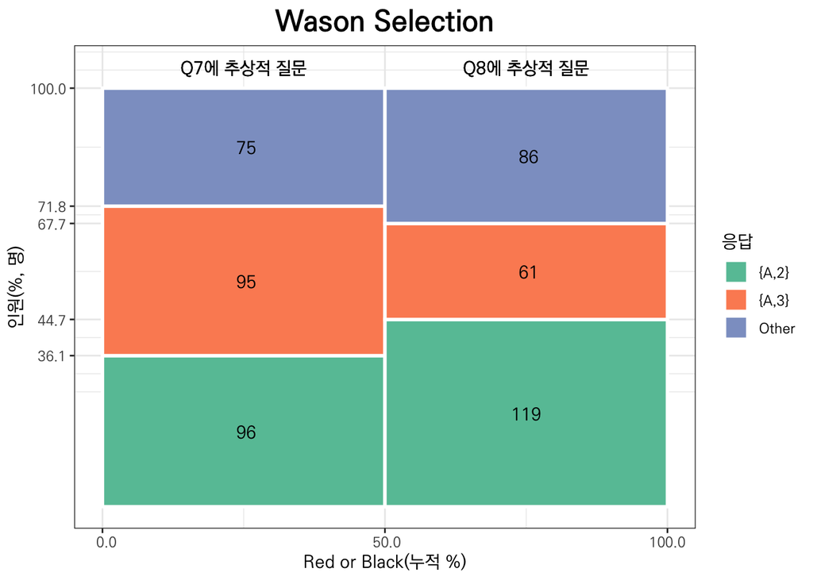

## 학습 순서의 영향

구체적 질문을 먼저 학습하고 추상적 질문을 학습하는 것과 추상적 질문을 먼저 학습하고 구체적 질문을 학습하는 방식 중에 어느 것이 더 나은지 비교한 결과 순서에 따른 정답인원의 차이에는 통계적으로 유의한 차이가 관찰되었습니다.

어떻게 해석할 수 있을까요?

추상적 문제를 먼저 학습하는 것이 효과적일까요?

이 문제에 대해서는 학기 마다 조금씩 다른 결과가 나옵니다.

### 집계표

Wason Selection

|  | 추상적 질문 정답 | 구체적 질문 정답 | 계 |
| --- | --- | --- | --- |
| **Red(추상적 질문 먼저)** | 101 | 152 | 253 |
| **Black(구체적 질문 먼저)** | 72 | 171 | 243 |

Pearson’s Chi-squared test with Yates’ continuity correction: `.`

| Test statistic | df | P value |
| --- | --- | --- |
| 5.335 | 1 | 0.0209 * |

추상적 질문을 Q7에 배치하고 구체적 질문을 Q8에 배치한 Red의 경우 추상적 질문과 구체적 질문에 정답을 올린 사람은 총 253(명)이고 구체적 질문을 Q7에 배치하고 추상적 질문을 Q8에 배치한 Black의 경우 추상적 질문과 구체적 질문에 정답을 올린 사람은 총 243(명)으로 별로 차이가 나지 않습니다.

그러나, 추상적 질문을 Q8에 배치한 Black 의 경우 72(명) 이 정답을 올렸고, 구체적 질문에는 171명이 정답을 올려서 통계적으로 유의한 차이를 관찰하였습니다.

카이제곱 통계량은 5.34, p-value 는 0.021으로 통계적으로 유의한 차이를 관찰하였습니다.

따라서 학습 순서는 추상적 질문의 정답율에 영향을 미치고 있습니다.

백분율을 살펴 보겠습니다.

### % 비교

Wason Selection

|  | 추상적 질문 정답 | 구체적 질문 정답 |
| --- | --- | --- |
| **Red(추상적 질문 먼저)** | 58.4 | 47.1 |
| **Black(구체적 질문 먼저)** | 41.6 | 52.9 |
| **계** | 100.0 | 100.0 |

추상적 질문에 대한 Red, Black 간 정답률 차이와 구체적 질문에 대한 Red, Black 간 정답률 차이를 비교하였습니다.

추상적 질문에 대한 전체 정답 중에서 추상적 질문을 먼저 제시한 Red 가 58.4(%)를 차지하여 추상적 질문을 나중에 제시한 Black 보다 높고, 그 차이는 앞에서 살펴 본 것처럼 통계적으로 유의합니다.

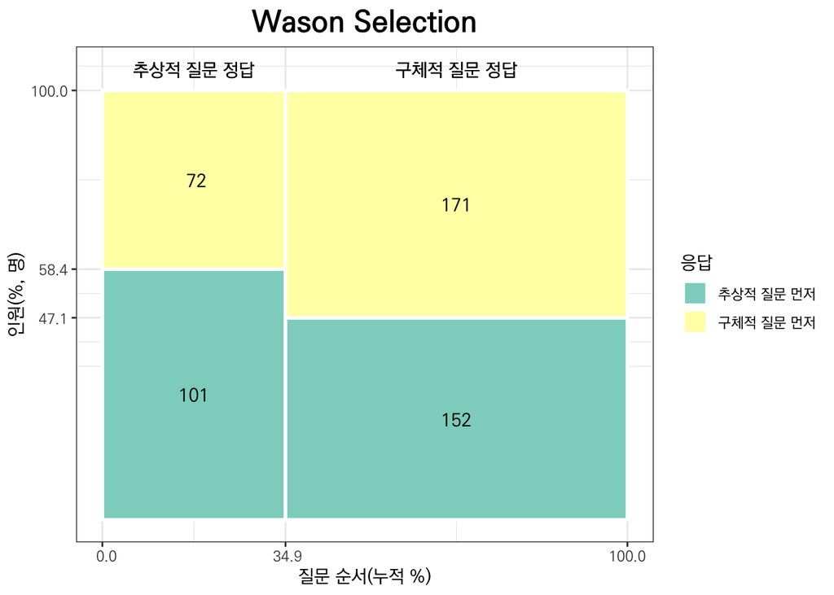

### 합산

실험에 참여한 어느 누구나 추상적 문제와 구체적 문제를 한 번씩 풀게 됩니다.

학습 순서의 영향이 있는 것으로 파악되었지만 추상적 문제의 정답률과 구체적 문제의 정답률을 합쳐서 비교해 보겠습니다.

### 집계표

|  | 정답 | 오답 | 계 |
| --- | --- | --- | --- |
| **추상적 문제** | 173 | 359 | 532 |
| **구체적 문제** | 323 | 209 | 532 |

추상적 질문에 답한 사람 총 532(명) 중에 정답을 올린 사람은 모두 173(명)이고 구체적 질문에 답한 사람 총 532(명) 중에 정답을 올린 사람은 모두 323(명)입니다. 백분율로 비교해 보면

### % 비교

|  | 정답 | 오답 | 계 |
| --- | --- | --- | --- |
| **추상적 문제** | 32.5 | 67.5 | 100.0 |
| **구체적 문제** | 60.7 | 39.3 | 100.0 |

추상적 질문의 정답율이 구체적 질문의 정답율에 비하여 월등히 낮다는 것을 알 수 있습니다. 이를 시각적으로 비교해 보겠습니다.

### Barplot

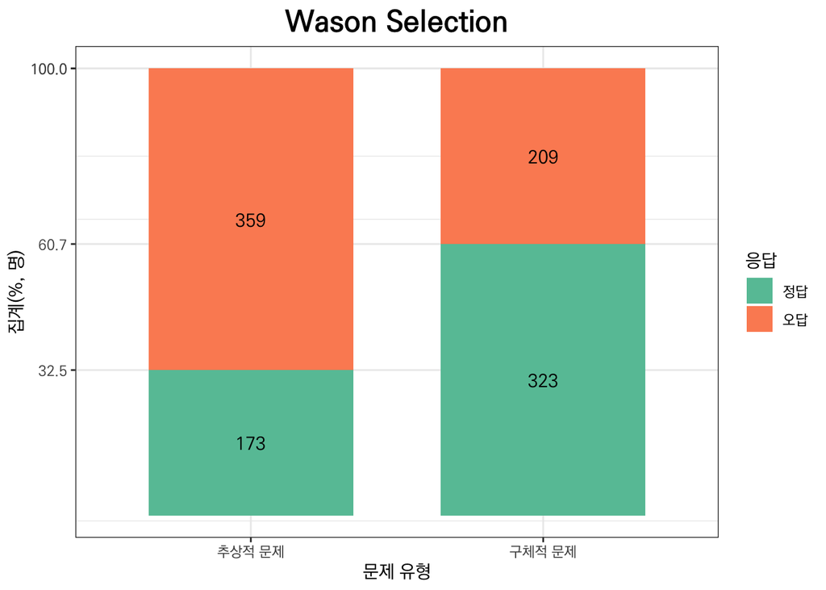

이 경우에는 막대그래프로 표현하는 것이 보다 시각적으로 두 상황을 비교하기에 더 효과적입니다.

추상적 질문의 응답 중에서 정답의 비율이 구체적 질문의 응답 중 정답의 비율보다 월등히 적다는 것이 시각적으로 잘 드러나고 있습니다.

## 마감 시간으로부터 제출 시간의 분포

### 분포표

일 단위

|  | [0,1] | (1,2] | (2,3] | (3,4] | (4,5] | (5,6] | (6,7] | (7,8] | (8,9] | (9,10] | (10,11] | (11,12] | (12,13] | (13,14] | 계 |
| --- | --- | --- | --- | --- | --- | --- | --- | --- | --- | --- | --- | --- | --- | --- | --- |
| **Red** | 104 | 21 | 5 | 9 | 1 | 0 | 1 | 25 | 14 | 16 | 12 | 16 | 18 | 24 | 266 |
| **Black** | 98 | 12 | 7 | 1 | 3 | 3 | 7 | 35 | 13 | 14 | 11 | 14 | 16 | 32 | 266 |
| **계** | 202 | 33 | 12 | 10 | 4 | 3 | 8 | 60 | 27 | 30 | 23 | 30 | 34 | 56 | 532 |

분포표로부터 두 가지 문제를 살펴보겠습니다.

첫째, 날마다 고르게 제출하는가?

둘째, Red, Black 간에 통계적으로 유의한 차이가 있는가?

각 문제를 살펴보기 위해서는 분포표의 일부분을 대상으로 카이제곱 테스트를 수행합니다.

### 날마다 고르게 제출하는가?

| [0,1] | (1,2] | (2,3] | (3,4] | (4,5] | (5,6] | (6,7] | (7,8] | (8,9] | (9,10] | (10,11] | (11,12] | (12,13] | (13,14] |
| --- | --- | --- | --- | --- | --- | --- | --- | --- | --- | --- | --- | --- | --- |
| 202 | 33 | 12 | 10 | 4 | 3 | 8 | 60 | 27 | 30 | 23 | 30 | 34 | 56 |

Chi-squared test for given probabilities: `.`

| Test statistic | df | P value |
| --- | --- | --- |
| 867.4 | 13 | 5.059e-177 * * * |

날마다 고르게 제출하는지 알아 보았습니다.

분포표의 “계”행에서 ’계’열을 제외하고 카이제곱테스트를 수행합니다.

분포표 만으로도 쉽게 파악할 수 있지만 카이제곱테스트가 명확히 해 줍니다.

카이제곱 통계량은 867.37, 자유도는 13.00, p-value 는 5.1e-177 이므로 날짜별로 고르게 제출하지 않았습니다.

그리고 그 차이는 통계적으로 매우, 매우 유의합니다.

막대그래프로 살펴 보겠습니다.

### 막대그래프

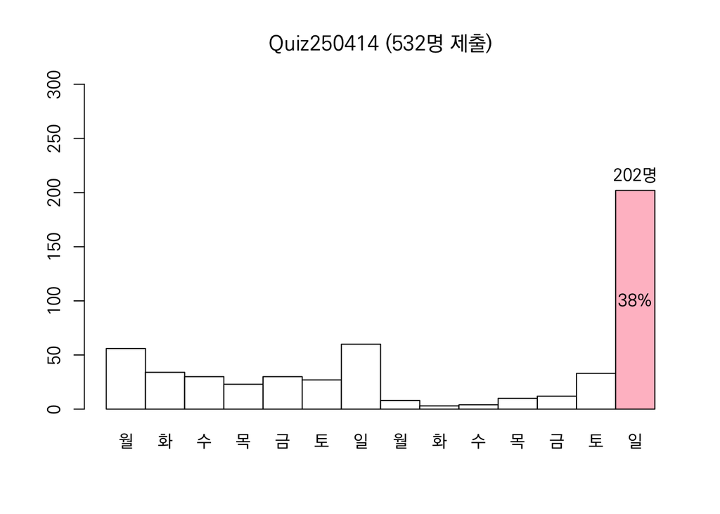

### Red, Black 간에 닮았는가?

|  | [0,1] | (1,2] | (2,3] | (3,4] | (4,5] | (5,6] | (6,7] | (7,8] | (8,9] | (9,10] | (10,11] | (11,12] | (12,13] | (13,14] |
| --- | --- | --- | --- | --- | --- | --- | --- | --- | --- | --- | --- | --- | --- | --- |
| **Red** | 104 | 21 | 5 | 9 | 1 | 0 | 1 | 25 | 14 | 16 | 12 | 16 | 18 | 24 |
| **Black** | 98 | 12 | 7 | 1 | 3 | 3 | 7 | 35 | 13 | 14 | 11 | 14 | 16 | 32 |

Pearson’s Chi-squared test: `.`

| Test statistic | df | P value |
| --- | --- | --- |
| 21.14 | 13 | 0.0702 |

제출시간의 분포가 Red, Black 간에 닮았는지 알아 보았습니다.

이번에는 분포표의 첫번째와 두번째 행, ’계’열을 제외한 나머지 열에 대해서 카이제곱테스트를 수행합니다.

카이제곱 통계량은 21.14, 자유도는 13, p-value 는 0.0702 이므로 제출 시간의 분포는 Red, Black 간에 통계적으로 유의한 차이가 관찰되지 않았습니다.

이 사실을 Mosaic Plot 을 이용하여 시각적으로 살펴보겠습니다.

닮았다고 느껴지나요?

### Mosaic Plot

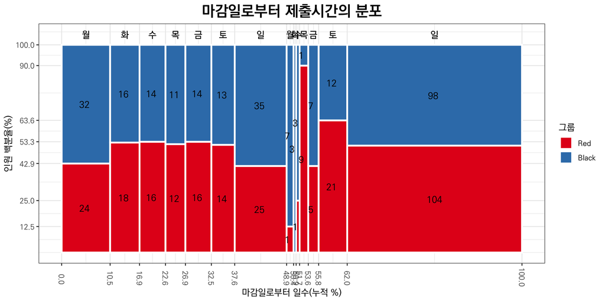